# Exploring the properties of red wine

Randy Tilson

04/01/2022

> **Red Wine Properties Data Exploration:** This dataset explores the properties of red wine as determined by the given variables displayed below

```
##  [1] "fixed.acidity"        "volatile.acidity"     "citric.acid"
##  [4] "residual.sugar"       "chlorides"            "free.sulfur.dioxide"
##  [7] "total.sulfur.dioxide" "density"              "pH"
## [10] "sulphates"            "alcohol"              "quality"
```

> **Total Data Entries:** As shown below

```
## [1] 19188
```

> **Thoughts regarding variables:** Given the variables, it is likely that “quality” is the best benchmark to measure against for correlations from within other variables.

# Data Summary

```
##  fixed.acidity   volatile.acidity  citric.acid    residual.sugar
##  Min.   : 4.60   Min.   :0.1200   Min.   :0.000   Min.   : 0.900
##  1st Qu.: 7.10   1st Qu.:0.3900   1st Qu.:0.090   1st Qu.: 1.900
##  Median : 7.90   Median :0.5200   Median :0.260   Median : 2.200
##  Mean   : 8.32   Mean   :0.5278   Mean   :0.271   Mean   : 2.539
##  3rd Qu.: 9.20   3rd Qu.:0.6400   3rd Qu.:0.420   3rd Qu.: 2.600
##  Max.   :15.90   Max.   :1.5800   Max.   :1.000   Max.   :15.500
##    chlorides       free.sulfur.dioxide total.sulfur.dioxide    density
##  Min.   :0.01200   Min.   : 1.00       Min.   :  6.00       Min.   :0.9901
##  1st Qu.:0.07000   1st Qu.: 7.00       1st Qu.: 22.00       1st Qu.:0.9956
##  Median :0.07900   Median :14.00       Median : 38.00       Median :0.9968
##  Mean   :0.08747   Mean   :15.87       Mean   : 46.47       Mean   :0.9967
##  3rd Qu.:0.09000   3rd Qu.:21.00       3rd Qu.: 62.00       3rd Qu.:0.9978
##  Max.   :0.61100   Max.   :72.00       Max.   :289.00       Max.   :1.0037
##        pH          sulphates         alcohol         quality
##  Min.   :2.740   Min.   :0.3300   Min.   : 8.40   Min.   :3.000
##  1st Qu.:3.210   1st Qu.:0.5500   1st Qu.: 9.50   1st Qu.:5.000
##  Median :3.310   Median :0.6200   Median :10.20   Median :6.000
##  Mean   :3.311   Mean   :0.6581   Mean   :10.42   Mean   :5.636
##  3rd Qu.:3.400   3rd Qu.:0.7300   3rd Qu.:11.10   3rd Qu.:6.000
##  Max.   :4.010   Max.   :2.0000   Max.   :14.90   Max.   :8.000
```

### Data summarized and grouped by quality rating

**Descriptive Statistics AS GROUPED BY Quality Rating**

| **Variables As grouped by quality rating** | **Bold = Quality Value, N = Quality Value Sum** **3**, N = 10<sup>1</sup> | **Bold = Quality Value, N = Quality Value Sum** **4**, N = 53<sup>1</sup> | **Bold = Quality Value, N = Quality Value Sum** **5**, N = 681<sup>1</sup> | **Bold = Quality Value, N = Quality Value Sum** **6**, N = 638<sup>1</sup> | **Bold = Quality Value, N = Quality Value Sum** **7**, N = 199<sup>1</sup> | **Bold = Quality Value, N = Quality Value Sum** **8**, N = 18<sup>1</sup> |
| --- | --- | --- | --- | --- | --- | --- |
| fixed.acidity | 7.50 (7.15, 9.88) | 7.50 (6.80, 8.40) | 7.80 (7.10, 8.90) | 7.90 (7.00, 9.40) | 8.80 (7.40, 10.10) | 8.25 (7.25, 10.23) |
| volatile.acidity | 0.84 (0.65, 1.01) | 0.67 (0.53, 0.87) | 0.58 (0.46, 0.67) | 0.49 (0.38, 0.60) | 0.37 (0.30, 0.48) | 0.37 (0.33, 0.47) |
| citric.acid | 0.04 (0.00, 0.33) | 0.09 (0.03, 0.27) | 0.23 (0.09, 0.36) | 0.26 (0.09, 0.43) | 0.40 (0.30, 0.49) | 0.42 (0.30, 0.53) |
| residual.sugar | 2.10 (1.88, 3.10) | 2.10 (1.90, 2.80) | 2.20 (1.90, 2.60) | 2.20 (1.90, 2.50) | 2.30 (2.00, 2.75) | 2.10 (1.80, 2.60) |
| chlorides | 0.090 (0.079, 0.143) | 0.080 (0.067, 0.089) | 0.081 (0.074, 0.094) | 0.078 (0.068, 0.088) | 0.073 (0.062, 0.087) | 0.071 (0.062, 0.076) |
| free.sulfur.dioxide | 6 (5, 14) | 11 (6, 15) | 15 (9, 23) | 14 (8, 21) | 11 (6, 18) | 8 (6, 16) |
| total.sulfur.dioxide | 15 (12, 42) | 26 (14, 49) | 47 (26, 84) | 35 (23, 54) | 27 (18, 43) | 22 (16, 43) |
| density | 0.9976 (0.9962, 0.9988) | 0.9965 (0.9956, 0.9974) | 0.9970 (0.9962, 0.9979) | 0.9966 (0.9954, 0.9979) | 0.9958 (0.9948, 0.9974) | 0.9949 (0.9942, 0.9972) |
| pH | 3.39 (3.31, 3.50) | 3.37 (3.30, 3.50) | 3.30 (3.20, 3.40) | 3.32 (3.22, 3.41) | 3.28 (3.20, 3.38) | 3.23 (3.16, 3.35) |
| sulphates | 0.54 (0.51, 0.62) | 0.56 (0.49, 0.60) | 0.58 (0.53, 0.66) | 0.64 (0.58, 0.75) | 0.74 (0.65, 0.83) | 0.74 (0.69, 0.82) |
| alcohol | 9.93 (9.72, 10.57) | 10.00 (9.60, 11.00) | 9.70 (9.40, 10.20) | 10.50 (9.80, 11.30) | 11.50 (10.80, 12.10) | 12.15 (11.33, 12.88) |

<sup>*1*</sup> As Shown, Variable Values Are: Median (IQR)

> Prior to plotting any variables, the data from within this table shows a few correlations already. It appears as if the variables of alcohol, sulphates, chlorides, citric.acid, and volatile.acidity are all are somewhat correlated to the quality rating.

# Univariate Plots Section

> With a lack of domain knowledge and a need to better understand the distributions, all variables will be charted in combination with their IQR. Also, standardized outlier markers will be put in place for better visualization of the distribution. In addition, the quality variable will be faceted together with each individual variable.

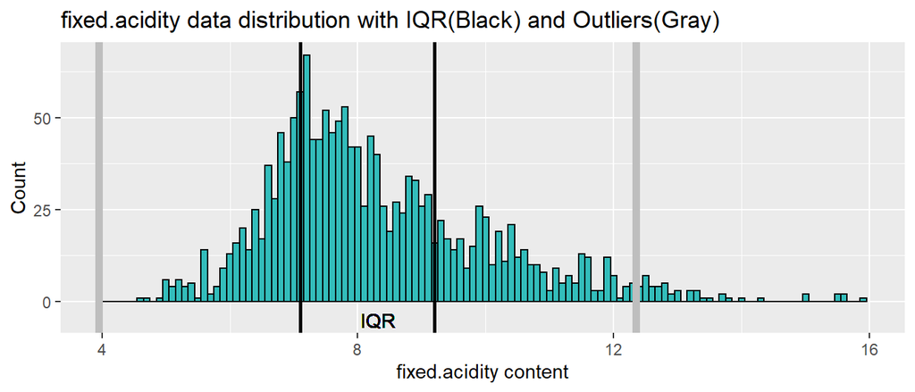

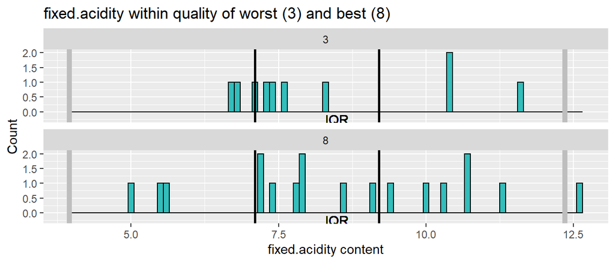

> **fixed.acidity:** Normal / slightly positive skewed distribution with outliers within the right tail. In looking at the quality facet, I do not see that much of a correlation between this variable and quality.

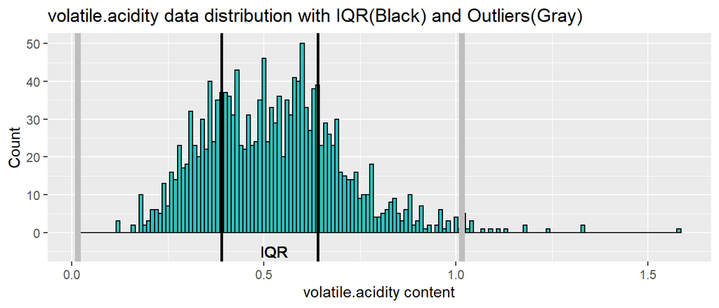

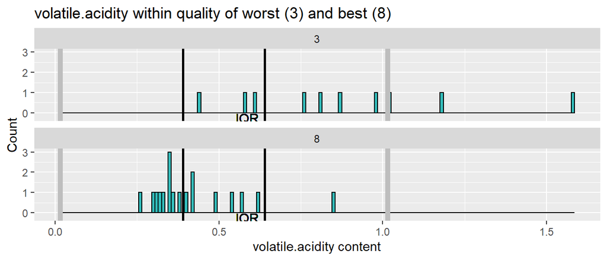

> **volatile.acidity:** Normal / slightly positive skewed distribution. Some outlier data within the right tail. It is possible that quality is affected by the content level of this variable with lower levels increasing the quality.

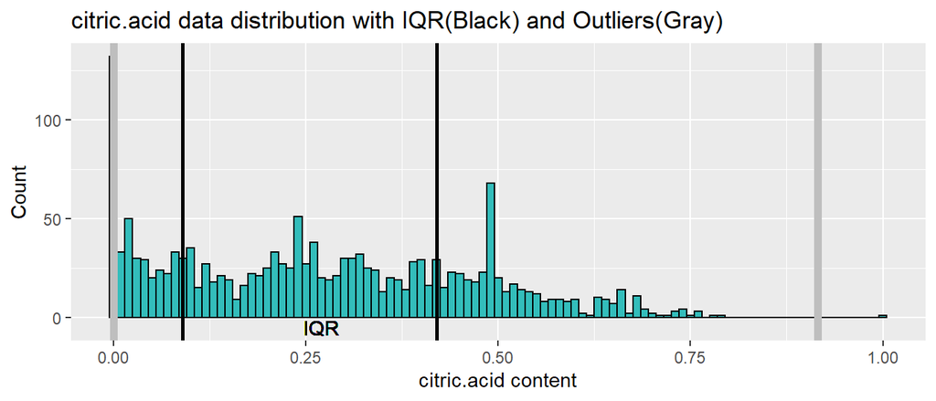

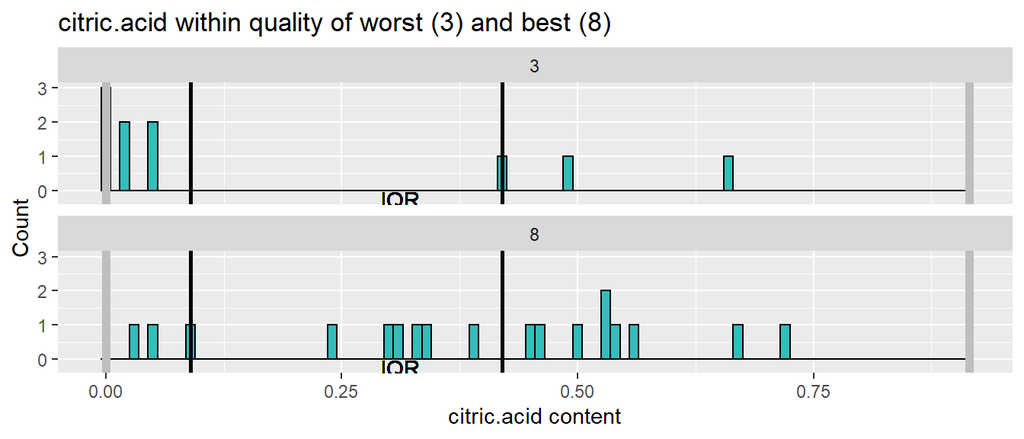

> **citric.acid:** The first thing that I notice is the first bar in the histogram, why are there so many zero values? I am not sure if this is possible for red wine. The structure is multi-modal, which so far is a unique quality. With it being multi-modal, there is a wide range of possible values without becoming outliers. I do want to disect the rest of the data and look for other zero values.

```
##        fixed.acidity     volatile.acidity          citric.acid
##                    0                    0                    8
##       residual.sugar            chlorides  free.sulfur.dioxide
##                    0                    0                    0
## total.sulfur.dioxide              density                   pH
##                    0                    0                    0
##            sulphates              alcohol              quality
##                    0                    0                    0
```

> In looking at the dataframe, 8% of all citric acid values are zero values, Whereas zero values do not exist within other variables. This does lead me to believe that this is these values should be removed given the uncertainty and uncommon nature of this.

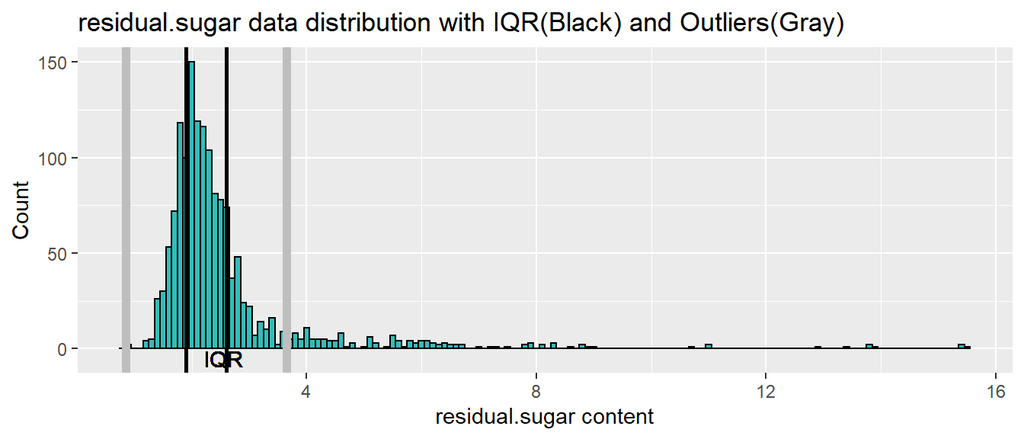

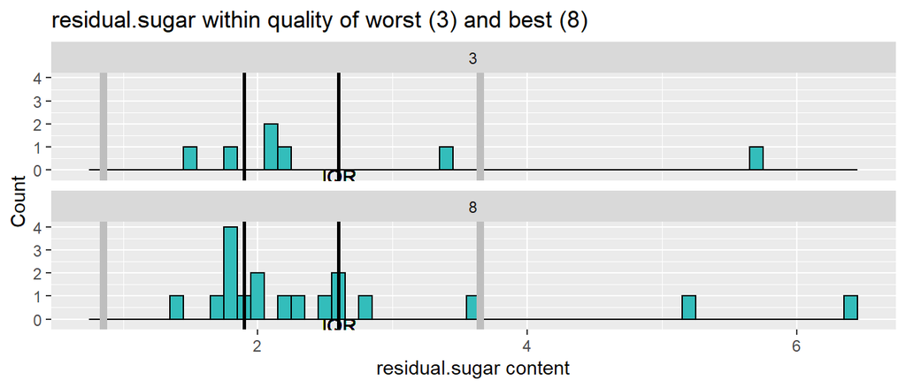

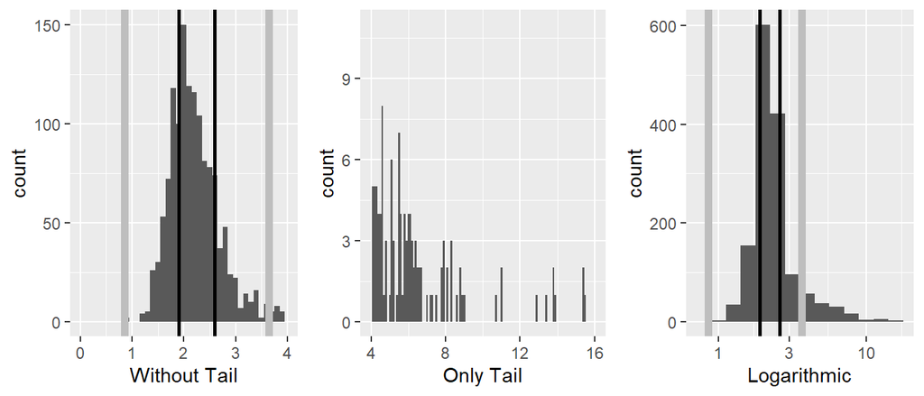

> **residual.sugar:** Normal / slightly positive skewed distribution with one sided outliers. The amount of outliers within the tail of this variable show a possible unique characteristic that would limit their discarding. In re-scaling and looking at the tail sections, it does appear that a fair amount of data exists past the technical outlier that lies just shy of 4. The correlation with quality seems to be lacking.

```
## Percent of original residual.sugar values that resides in the tail.
## Ordered from lowest to highest quality rating
```

```
## [1] 14.28571
## [1] 18.60465
## [1] 9.775641
## [1] 8.561644
## [1] 16.75393
## [1] 16.66667
```

> In performing a calculation on the percent of each quality that resides within the tail, it appears as if the mid grade wines have the lowest amount of data within the tail. This would infer that both the high grade and low grade wines possibly hold a higher content of this variable. This could also be a result of the law of large number as well, given that the mid grade wines have a much higher total count to where more data is available. This can be looked at in further detail within multivariate observations.

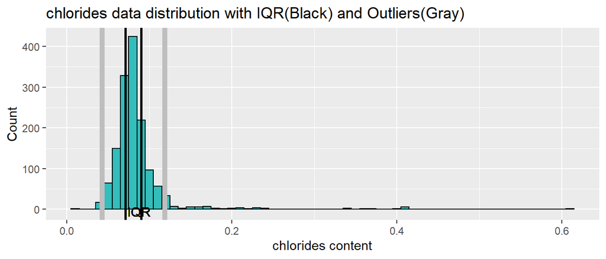

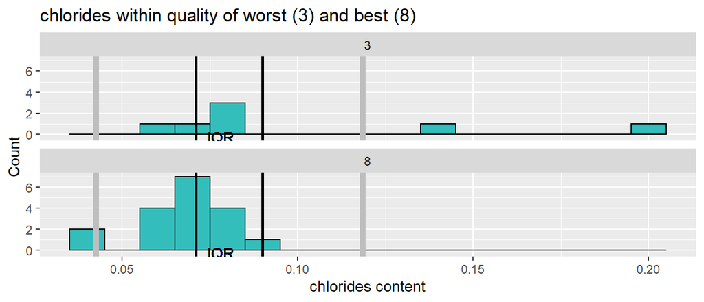

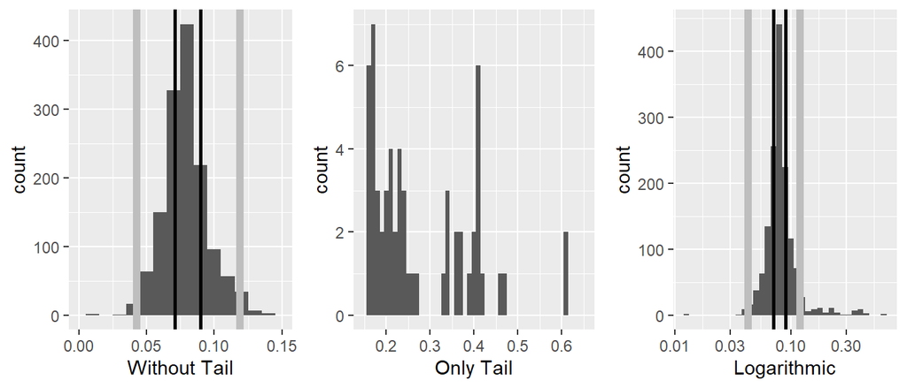

> **chlorides:** This distribution is similiar to sugar with a very normal distribution followed by a very long tail to the right. Of difference though would be the possible correlation with quaility. Because of the tail, a logarithmic view was created, however the view seems inconclusive other than showing a small distribution past the .30 range. It would appear as if lower chlorides may lead to higher quality wines

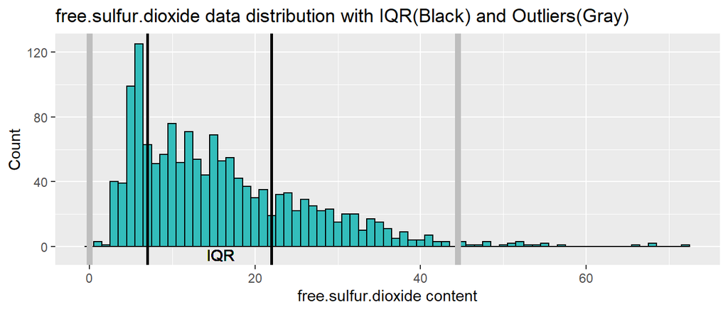

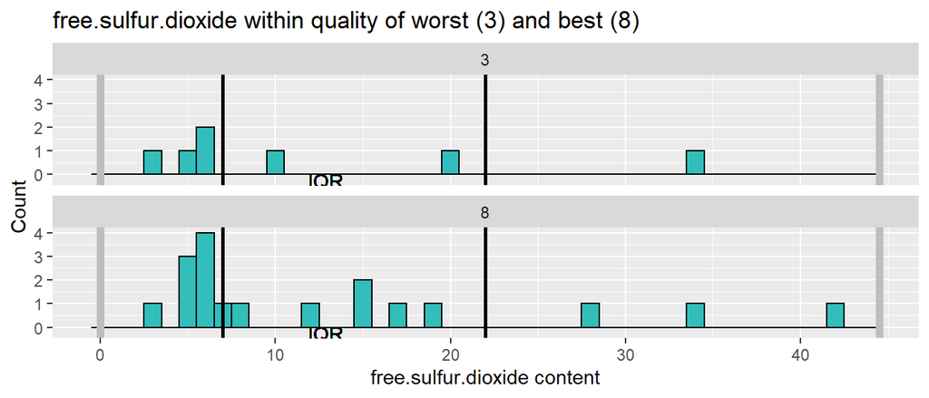

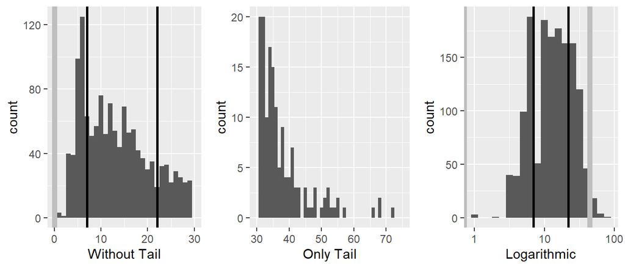

> **free.sulfur.dioxide:** Positive skew with a large amount of data falling outside of Q1. Log scale shows a more even distribution. Also, it is a pretty even distribution amongst the low and high quality which does not lead me towards correlation with quality.

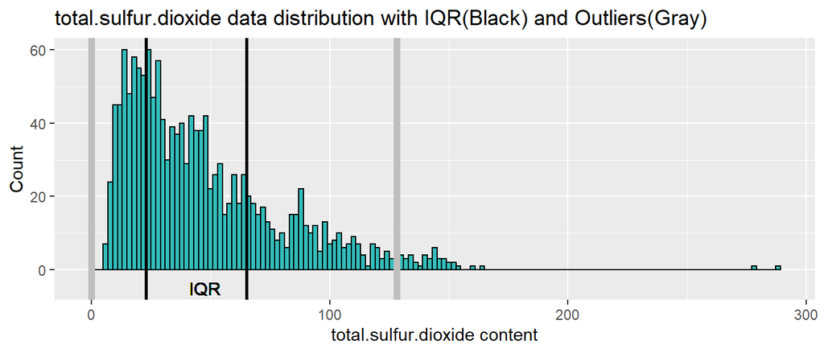

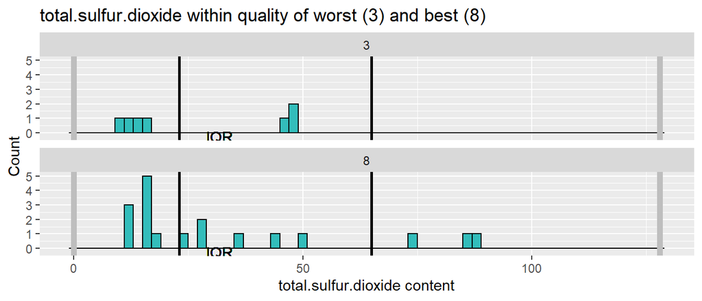

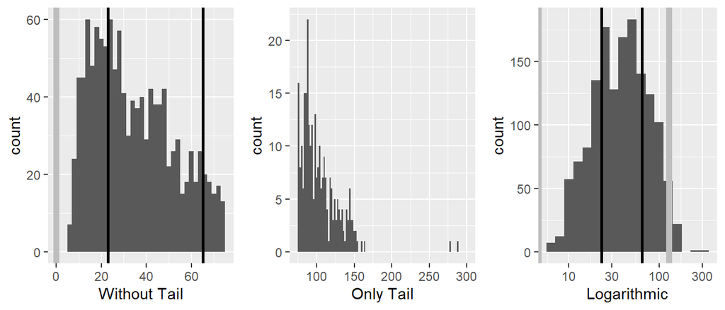

> **total.sulfur.dioxide:** Similar distribution to that of free.sulfur.dioxide. This would make sense given that they are measurements of similar properties. Rescaling it logarithmically shows a more even distribution as well. Its possible that higher values lead to higher quality, but it is certainly not a strong correlation so far.

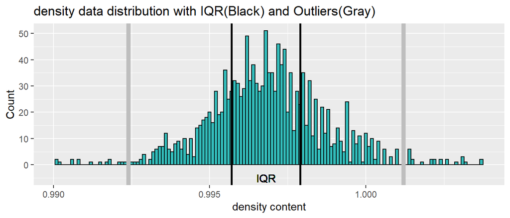

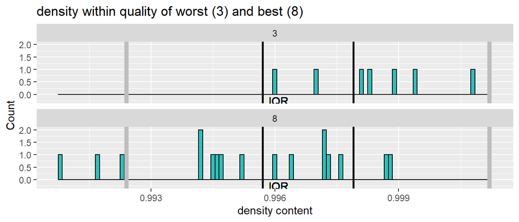

> **density:** Very normal distribution with outliers in the left and right tail. Given the normalized distribution, I am not going to look into any tail features. It appears as if a lower density may lead to a higher quality wine.

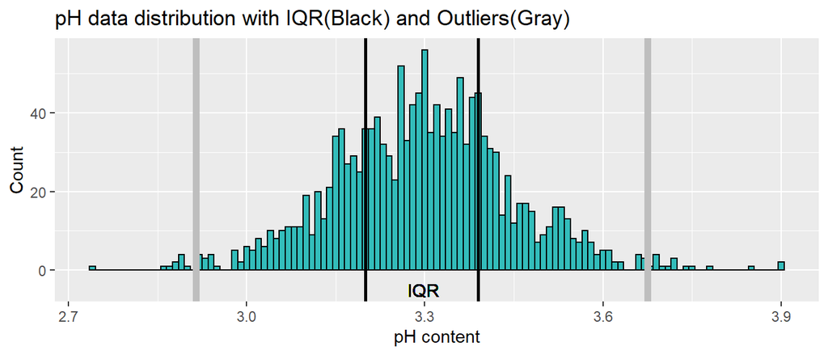

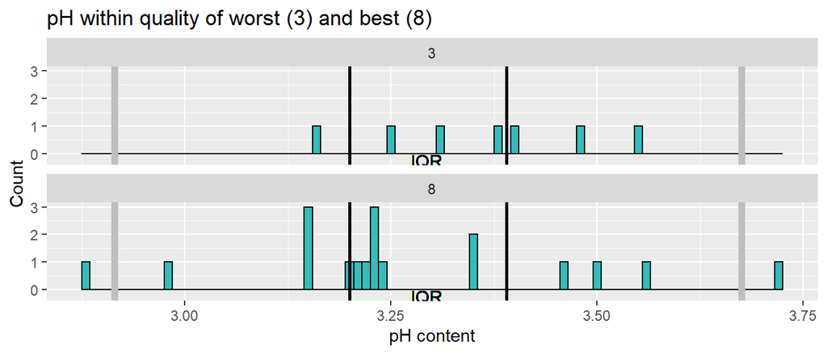

> **pH:** Normal distribution similiar to that of density. A possible small correlation may exist though, with lower pH equaling higher quality.

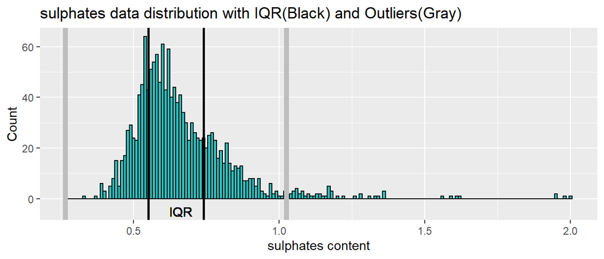

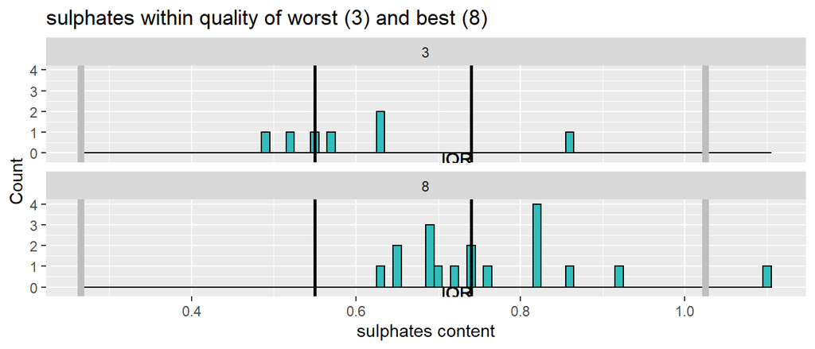

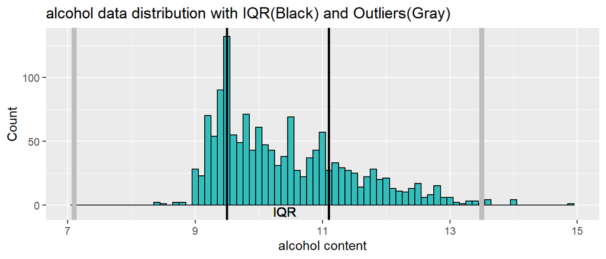

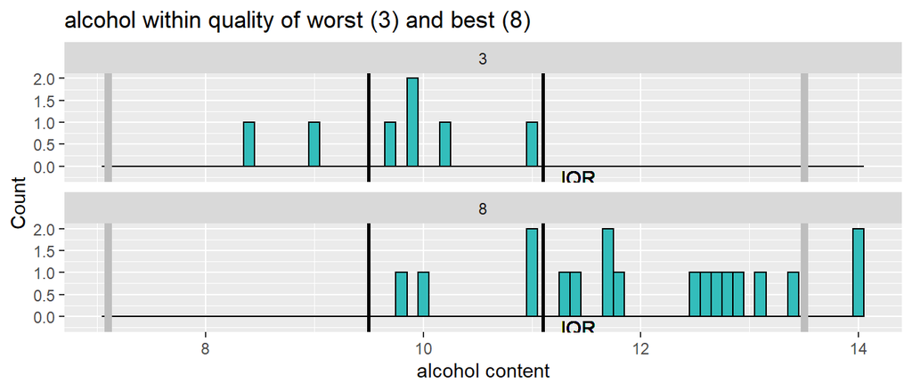

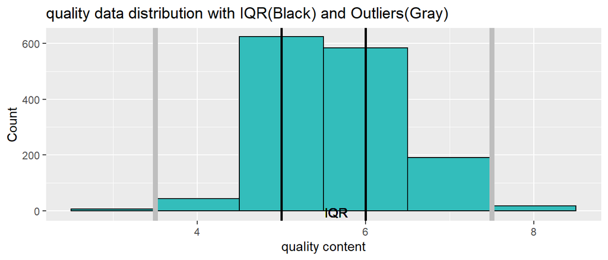

> **quality:** Normal distribution with the majority of ratings being that of 5 and 6.

# Univariate Analysis

#### **Dataset structure:**

This dataset has both normalized and positively skewed distributions. Within the skewed distributions, all outliers lie within the right tail. In some cases, the outliers appear to be more than outliers, this may point to conditions that are rare but very possible.

#### **Main feature of interest:**

The main feature of interest is the quality variable and any given correlations from within the remaining variables of the dataset.

#### **Dataset features to help investigate the main feature of interest:**

The numerous apparent correlations will be very helpful to examine, particularly within the alcohol content.

#### **New variables:**

As of now, new variables have not been created. This may change as I proceed into bivariate and multivariate, however at this time the variables seem sufficient.

#### **Unusual features and data cleaning:**

First of all, I subsetted the dataframe to remove the x variable, which I determined not necessary for my analysis. Then The zero values within citric acid grabbed my attention. Because of this, the dataframe was examined further to ensure this anomaly was isolated within this one specific variable. Given that they were, these values were removed to ensure data completeness. Also, in separating out the numerous outlier values within residual sugar, I was surprised to see that the low and high grade wines hold a larger percent of the outlier data. As noted though, this could easily be due to a larger amount of data being available from other quality ratings, which could possibly lower their percentages to a more representative value. Lastly, it seems as if the data is either structured with a positive skew, or normalized distribution, with some of these variables looking very similar in structure.

In general, the data is and was fairly clean and ready to examine outside of the zero values from within citric.acid

# Bivariate Plots Section

> In moving forward, I would like to further examine the relationships between these variables. Based on my univariate analysis, I already have some assumptions towards possible correlations, specifically the correlation between alcohol and the quality rating. I would like to start with a full data overview of all variables as compared to quality. This may expose any other correlations within the quality rating, or within supporting variables.

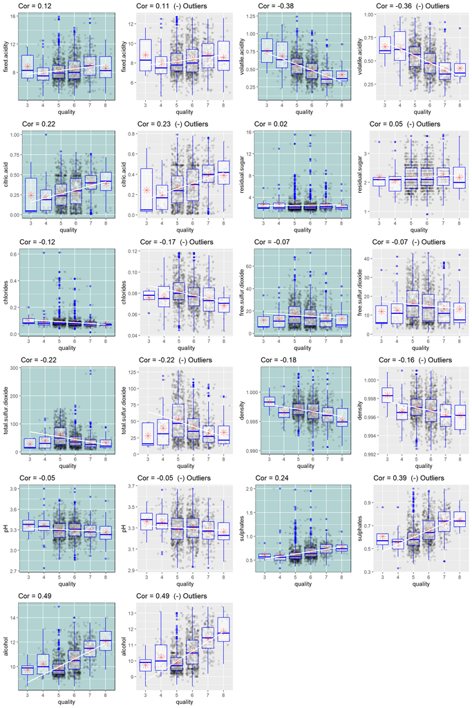

> This grid plots the overall distribution of each variable as it relates to the quality rating. A linear regression line and associated correlation values are also plotted within each variable. This provides a clear view towards the positive and negative correlated values. Volatile.acidity appears to have a small negative correlation, while alcohol is closer to a moderate correlation. Also, I can see the outlier data within residual.sugar and its association between quality levels much more clear now. Most of these variables do contain a lot of outlier data.

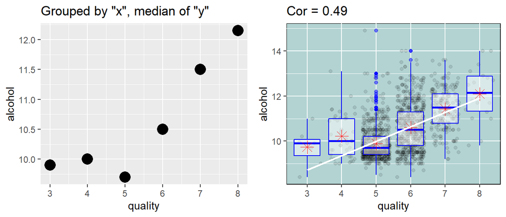

> Plotting the main feature of quality rating with the variable of strongest correlation, alcohol. The chart on the left represents the median alcohol content value at each quality level. I would like to explore which supporting variables may have the highest correlation value with alcohol in an effort to isolate any dependencies.

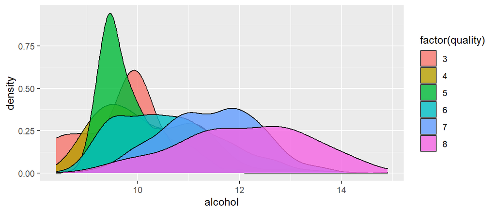

> Showing the alcohol density at each quality level

```
##                      fixed.acidity volatile.acidity citric.acid residual.sugar
## fixed.acidity           1.00000000      -0.23591004  0.65954351   0.1018064623
## volatile.acidity       -0.23591004       1.00000000 -0.52350778   0.0150139714
## citric.acid             0.65954351      -0.52350778  1.00000000   0.1306422974
## residual.sugar          0.10180646       0.01501397  0.13064230   1.0000000000
## chlorides               0.08682118       0.05834564  0.21590904   0.0495191881
## free.sulfur.dioxide    -0.16278828       0.01838999 -0.07808537   0.1916337992
## total.sulfur.dioxide   -0.14523547       0.13801243 -0.02196773   0.1975306908
## density                 0.66455621       0.04330891  0.35988028   0.3510773624
## pH                     -0.66847091       0.18315799 -0.50499704  -0.0686189003
## sulphates               0.17685624      -0.24317776  0.30832676   0.0003495688
## alcohol                -0.02722621      -0.22183274  0.14293145   0.0548729369
## quality                 0.12365152      -0.37716175  0.22048370   0.0189329994
##                         chlorides free.sulfur.dioxide total.sulfur.dioxide
## fixed.acidity         0.086821179        -0.162788285          -0.14523547
## volatile.acidity      0.058345641         0.018389993           0.13801243
## citric.acid           0.215909039        -0.078085372          -0.02196773
## residual.sugar        0.049519188         0.191633799           0.19753069
## chlorides             1.000000000         0.009803183           0.04903671
## free.sulfur.dioxide   0.009803183         1.000000000           0.67243555
## total.sulfur.dioxide  0.049036711         0.672435547           1.00000000
## density               0.194901914        -0.018398693           0.06198103
## pH                   -0.272670673         0.084615857          -0.03944042
## sulphates             0.391103067         0.039847271           0.02027708
## alcohol              -0.217817835        -0.084898054          -0.22444159
## quality              -0.123382491        -0.067668038          -0.21855959
##                          density          pH     sulphates     alcohol
## fixed.acidity         0.66455621 -0.66847091  0.1768562418 -0.02722621
## volatile.acidity      0.04330891  0.18315799 -0.2431777623 -0.22183274
## citric.acid           0.35988028 -0.50499704  0.3083267628  0.14293145
## residual.sugar        0.35107736 -0.06861890  0.0003495688  0.05487294
## chlorides             0.19490191 -0.27267067  0.3911030671 -0.21781783
## free.sulfur.dioxide  -0.01839869  0.08461586  0.0398472707 -0.08489805
## total.sulfur.dioxide  0.06198103 -0.03944042  0.0202770805 -0.22444159
## density               1.00000000 -0.31741098  0.1432001261 -0.46523355
## pH                   -0.31741098  1.00000000 -0.2047777092  0.17354874
## sulphates             0.14320013 -0.20477771  1.0000000000  0.09082713
## alcohol              -0.46523355  0.17354874  0.0908271338  1.00000000
## quality              -0.17869845 -0.04984500  0.2373255704  0.48927491
##                          quality
## fixed.acidity         0.12365152
## volatile.acidity     -0.37716175
## citric.acid           0.22048370
## residual.sugar        0.01893300
## chlorides            -0.12338249
## free.sulfur.dioxide  -0.06766804
## total.sulfur.dioxide -0.21855959
## density              -0.17869845
## pH                   -0.04984500
## sulphates             0.23732557
## alcohol               0.48927491
## quality               1.00000000
```

> A correlation table will be useful to hone in on any other possible correlated variables. Given that alcohol has the strongetst correlation within quality, I would like to follow alcohol and identify a trail of association from within it. If possible, I would like to follow each strongest correlation to the next in an effort to unfold any possible patterns.

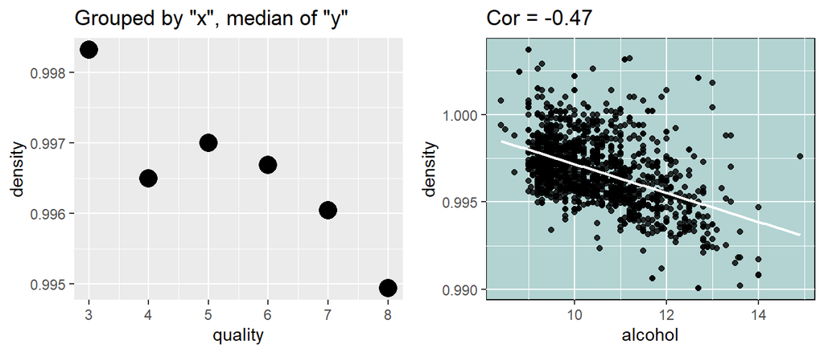

> Density is the strongest correlation with alcohol, the negative association with quality can also be seen within the plot to the upper left.